# Case Study 1 - Budweiser EDA

Kosi Okeke

2024-03-09

# Introduction

This document presents an exploratory data analysis (EDA) performed on a dataset containing both the Beers and Breweries csv’s. The analysis aims to uncover many different insights and patterns within the data.

# Loading Necessary Libraries

```r
library(tm)
library(tidyr)
library(plyr)
library(jsonlite)
library(dplyr)
library(tidyverse)
library(stringr)
library(class)
library(caret)
library(e1071)
library(mvtnorm)
library(magrittr)
```

# Reading the Beers and Breweries Data

Note: I’m also creating a ‘Brew_ID’ field in the beers df so that I can eventually merge my data frames.

```r
beers_df = read.csv(file.choose(), header = TRUE)
breweries_df = read.csv(file.choose(), header = TRUE)

beers_df$Brew_ID <- beers_df$Brewery_id
```

# 1. How Many Breweries Are Present in Each State?

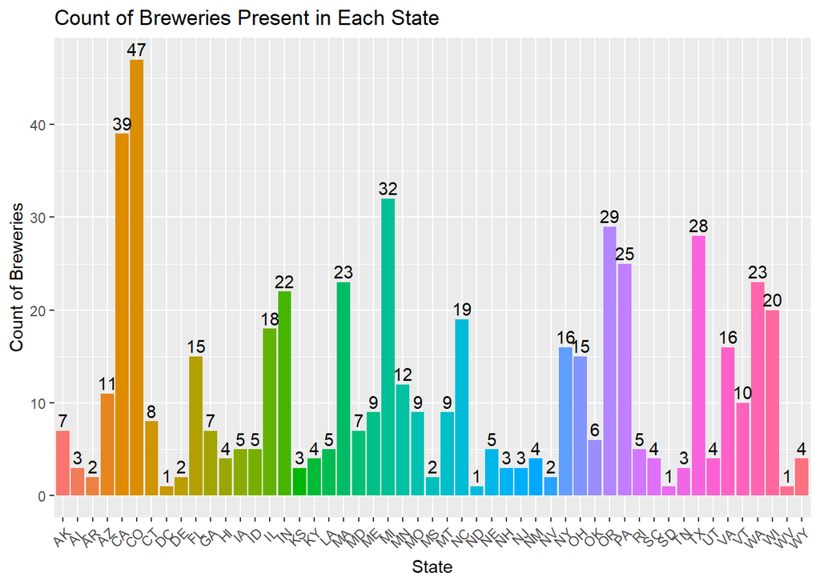

```r
breweries_df %>%
  count(State) %>% # Count the number of breweries in each state directly
  ggplot(aes(x = State, y = n, fill = State)) + # Use 'n' for counts
  geom_bar(stat = "identity") + # Specify that we're using pre-computed counts
  geom_text(aes(label = n), vjust = -0.3, color = "black") + # Add count labels above bars
  ggtitle("Count of Breweries Present in Each State") +
  theme(
    legend.position = "none",
    axis.text.x = element_text(angle = 45, hjust = 1) # Improve x-axis label readability
  ) +
  xlab("State") +
  ylab("Count of Breweries")
```

As you can see, there is a wide range of breweries across all the states. Some important ones to note are Colorado with the most breweries with 47, California in second with 39, and Michigan in third with 32.

# 2. Merge Beer Dataframe w/ the Breweries Dataframe. Print the First 6 Observations and the Last Six Observations to Check the Merged File.

Note: This is the main df I will be using for my analysis.

```r
#joining on Brew_ID
beers_breweries <- left_join(beers_df,breweries_df, by = "Brew_ID")

# first six Observations
head(beers_breweries, 6)
```

```
##                Name.x Beer_ID   ABV IBU Brewery_id
## 1            Pub Beer    1436 0.050  NA        409
## 2         Devil's Cup    2265 0.066  NA        178
## 3 Rise of the Phoenix    2264 0.071  NA        178
## 4            Sinister    2263 0.090  NA        178
## 5       Sex and Candy    2262 0.075  NA        178
## 6        Black Exodus    2261 0.077  NA        178
##                            Style Ounces Brew_ID                    Name.y City
## 1            American Pale Lager     12     409 10 Barrel Brewing Company Bend
## 2        American Pale Ale (APA)     12     178       18th Street Brewery Gary
## 3                   American IPA     12     178       18th Street Brewery Gary
## 4 American Double / Imperial IPA     12     178       18th Street Brewery Gary
## 5                   American IPA     12     178       18th Street Brewery Gary
## 6                  Oatmeal Stout     12     178       18th Street Brewery Gary
##   State
## 1    OR
## 2    IN
## 3    IN
## 4    IN
## 5    IN
## 6    IN
```

```r
# last six observations
tail(beers_breweries, 6)
```

```
##                           Name.x Beer_ID   ABV IBU Brewery_id
## 2405 Rocky Mountain Oyster Stout    1035 0.075  NA        425
## 2406                   Belgorado     928 0.067  45        425
## 2407               Rail Yard Ale     807 0.052  NA        425
## 2408             B3K Black Lager     620 0.055  NA        425
## 2409         Silverback Pale Ale     145 0.055  40        425
## 2410        Rail Yard Ale (2009)      84 0.052  NA        425
##                         Style Ounces Brew_ID                  Name.y   City
## 2405           American Stout     12     425 Wynkoop Brewing Company Denver
## 2406              Belgian IPA     12     425 Wynkoop Brewing Company Denver
## 2407 American Amber / Red Ale     12     425 Wynkoop Brewing Company Denver
## 2408              Schwarzbier     12     425 Wynkoop Brewing Company Denver
## 2409  American Pale Ale (APA)     12     425 Wynkoop Brewing Company Denver
## 2410 American Amber / Red Ale     12     425 Wynkoop Brewing Company Denver
##      State
## 2405    CO
## 2406    CO
## 2407    CO
## 2408    CO
## 2409    CO
## 2410    CO
```

```r
# Creating Name fields and dropping R-given names
beers_breweries$Beer_Name = beers_breweries$Name.x
beers_breweries$Brewery_Name = beers_breweries$Name.y

beers_breweries <-
  beers_breweries %>%
  select(-c(Name.y, Name.x, Brew_ID))
```

# 3. Address the Missing Values in Each Column

```r
# investigating which columns have missing values
missing_counts <- data.frame(sapply(beers_breweries, function(x) sum(is.na(x))))

colsums = data.frame(colSums(beers_breweries == "", na.rm = TRUE))

missing_counts$Variable <- rownames(missing_counts)
colsums$Variable <- rownames(colsums)

# Rename the counts columns for clarity
names(missing_counts)[1] <- "NA_Count"
names(colsums)[1] <- "Empty_String_Count"

# Merge the data frames by the common column 'Variable'
combined_counts <- merge(missing_counts, colsums, by = "Variable")

# View the combined data frame
combined_counts
```

```
##        Variable NA_Count Empty_String_Count
## 1           ABV       62                  0
## 2       Beer_ID        0                  0
## 3     Beer_Name        0                  0
## 4    Brewery_id        0                  0
## 5  Brewery_Name        0                  0
## 6          City        0                  0
## 7           IBU     1005                  0
## 8        Ounces        0                  0
## 9         State        0                  0
## 10        Style        0                  5
```

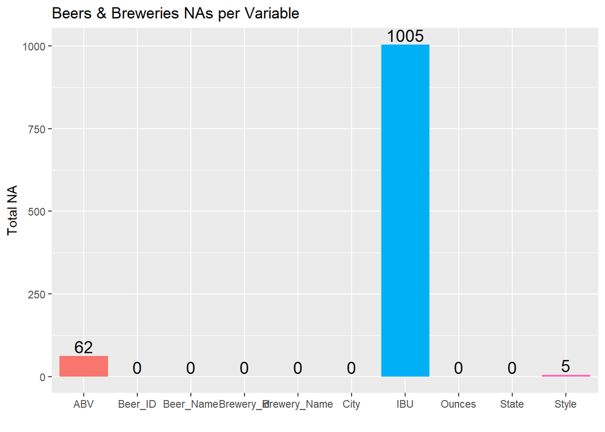

```r
combined_counts$total = combined_counts$NA_Count + combined_counts$Empty_String_Count
ggplot(combined_counts, aes(x = Variable, y = total))+
  geom_bar( aes(fill = Variable),stat = "identity")+
  geom_text(aes(label = total)
            , vjust = -0.25, size = 5, color = "black") +
  ylab("Total NA")+
  xlab("")+
  ggtitle("Beers & Breweries NAs per Variable")+
  theme(legend.position = "none")
```

```r
# ABv = 62
# IBU = 1005
# Style = 5

# checking for patterns
beers_breweries %>%
  group_by(Style) %>%
  filter(is.na(IBU)) %>%
  count() %>%
  arrange(desc(n))
```

```
## # A tibble: 89 × 2
## # Groups:   Style [89]
##    Style                              n
##    <chr>                          <int>
##  1 American IPA                     123
##  2 American Pale Ale (APA)           92
##  3 American Amber / Red Ale          56
##  4 American Blonde Ale               47
##  5 Cider                             37
##  6 American Pale Wheat Ale           36
##  7 American Brown Ale                32
##  8 American Double / Imperial IPA    30
##  9 American Porter                   29
## 10 Saison / Farmhouse Ale            29
## # ℹ 79 more rows
```

```r
#Find the most common style
most_common_style <- beers_breweries %>%
  filter(!is.na(Style)) %>%
  group_by(Style) %>%
  summarize(count = n()) %>%
  arrange(desc(count)) %>%
  slice(1) %>%
  pull(Style)

most_common_style
```

```
## [1] "American IPA"
```

```r
#American IPA


# Then, impute missing Style values
beers_breweries$Style <- ifelse(beers_breweries$Style == "", most_common_style, beers_breweries$Style)
colSums(beers_breweries == "", na.rm = TRUE)
```

```
##      Beer_ID          ABV          IBU   Brewery_id        Style       Ounces
##            0            0            0            0            0            0
##         City        State    Beer_Name Brewery_Name
##            0            0            0            0
```

```r
# Since deleting 1005 ibu or 62 abv values could be detrimental to our analysis, I will impute the values using the mean or median this function checks for NA values, then replaces them with the mean of the ABV values without the NA's.
mean_Abv <-
  beers_breweries %>%
  group_by(Style) %>%
  summarise(mean_abv = mean(ABV, na.rm = TRUE)) %>%
  mutate(mean_aBV = mean_abv)

# joining mean_abv to main df
beers_breweries = left_join(beers_breweries,mean_Abv, by = "Style")

beers_breweries$ABV <- ifelse(is.na(beers_breweries$ABV), beers_breweries$mean_abv, beers_breweries$ABV)


# sanity check
missing_counts <- sapply(beers_breweries, function(x) sum(is.na(x)))
print(missing_counts)
```

```
##      Beer_ID          ABV          IBU   Brewery_id        Style       Ounces
##            0            0         1005            0            0            0
##         City        State    Beer_Name Brewery_Name     mean_abv     mean_aBV
##            0            0            0            0            0            0
```

```r
# this function checks for NA values, then replaces them with the mean of the IBU values without the NA's due to its potential skewed distribution
mean_IBU <-
  beers_breweries %>%
  group_by(Style) %>%
  summarise(mean_IBU = mean(IBU, na.rm = TRUE)) %>%
  mutate(mean_ibu = mean_IBU)

# joining mean_IBU to main df
beers_breweries = left_join(beers_breweries,mean_IBU, by = "Style")

beers_breweries$IBU <- ifelse(is.na(beers_breweries$IBU),
                              beers_breweries$mean_ibu, beers_breweries$IBU)

# sanity check 2
missing_counts <- sapply(beers_breweries, function(x) sum(is.na(x)))
print(missing_counts)
```

```
##      Beer_ID          ABV          IBU   Brewery_id        Style       Ounces
##            0            0           52            0            0            0
##         City        State    Beer_Name Brewery_Name     mean_abv     mean_aBV
##            0            0            0            0            0            0
##     mean_IBU     mean_ibu
##           52           52
```

```r
beers_breweries <-
  beers_breweries %>%
    filter(!is.na(IBU))
```

To get rid of the NA’s we use a measure of center (mean) and impute. In both instances we take the mean of the ABV and IBU for each style of beverage, then replace the NA value in the ABV column based on the Style of beverage it is. This takes care of the 62 NA’s for “ABV” column. We do the same for the IBU column. Lastly, to address the NA’s under “Style” we took the mode (another measure of center) and replaced the five NA’s with the most popular Style.

# 4. Compute the Median Alcohol Content and International Bitterness Unit for Each State. Plot a Bar Chart to Compare.

## Plotting Median IBU

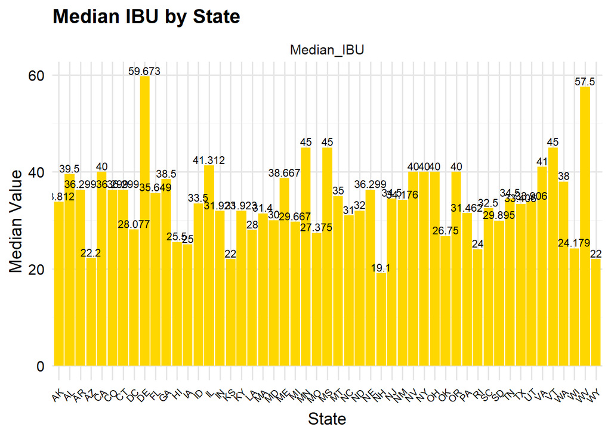

```r
beers_breweries %>%
  select(ABV, IBU, State) %>%
  group_by(State) %>%
  summarise(Median_IBU = median(IBU)) %>%
  gather(key = "Metric", value = "Median_Value", -State) %>%
  ggplot(aes(x = State, y = Median_Value, fill = Metric))+
           geom_bar(stat = "identity", position = "dodge") +
           theme_minimal() +
  labs(title = "Median IBU by State",
       x = "State",
       y = "Median Value") +
  scale_fill_manual(values = c("Median_IBU" = "#FFD700")) +
  geom_text(aes(label = round(Median_Value, 3)),position = position_dodge(width = 0.9), vjust = -0.25, size = 3, color = "black") +
  theme_minimal(base_size = 14) +
  theme(
    plot.background = element_blank(),
    panel.background = element_blank(),
    panel.grid.major = element_line(color = "gray90"),
    panel.grid.minor = element_line(color = "gray95"),
    plot.title = element_text(face = "bold", size = 16, color = "black"),
    axis.title = element_text(size = 14, color = "black"),
    axis.text = element_text(size = 12, color = "black"),
    axis.text.x = element_text(angle = 45, hjust = 1, size = 8),
    legend.position = "none"
  )+
  facet_wrap(~Metric, scales = "free_y")
```

## Plotting Median ABV

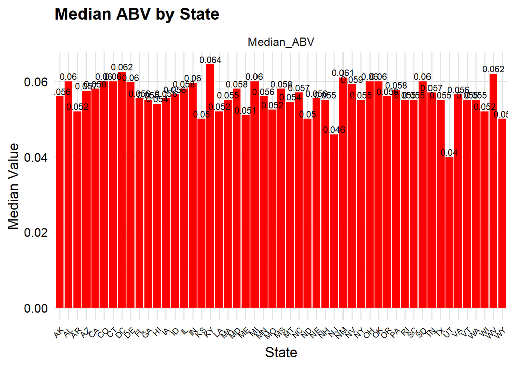

```r
beers_breweries %>%
  select(ABV, IBU, State) %>%
  group_by(State) %>%
  summarise(Median_ABV = median(ABV)) %>%
  gather(key = "Metric", value = "Median_Value", -State) %>%
  ggplot(aes(x = State, y = Median_Value, fill = Metric))+
  geom_bar(stat = "identity", position = "dodge") +
  theme_minimal() +
  labs(title = "Median ABV by State",
       x = "State",
       y = "Median Value") +
  scale_fill_manual(values = c("Median_ABV" = "#FF0000")) +
  geom_text(aes(label = round(Median_Value, 3)),position = position_dodge(width = 0.9), vjust = -0.25, size = 3, color = "black") +
  theme_minimal(base_size = 14) +
  theme(
    plot.background = element_blank(),
    panel.background = element_blank(),
    panel.grid.major = element_line(color = "gray90"),
    panel.grid.minor = element_line(color = "gray95"),
    plot.title = element_text(face = "bold", size = 16, color = "black"),
    axis.title = element_text(size = 14, color = "black"),
    axis.text = element_text(size = 12, color = "black"),
    axis.text.x = element_text(angle = 45, hjust = 1, size = 8),
    legend.position = "none"
  )+
  facet_wrap(~Metric, scales = "free_y")
```

Delaware leads in median IBU at ~ 60. Kentucky leads in median ABV at 6.4%. West Virginia is in the top two for both ABV and IBU, but there was only 1 brewery recorded in West Virginia which could be skewing those numbers due to the small sample size.

# 5. Which State Has the Maximum Alcoholic (ABV) Beer? Which State Has the Most Bitter (IBU) Beer?

```r
abv_ibu <-
  beers_breweries %>%
  select(ABV, IBU, State) %>%
  group_by(State)

# finding which state has highest abv
abv_ibu[which.max(abv_ibu$ABV),]    # Colorado - 12.8%
```

```
## # A tibble: 1 × 3
## # Groups:   State [1]
##     ABV   IBU State
##   <dbl> <dbl> <chr>
## 1 0.128    24 " CO"
```

```r
# finding which state has highest ibu
abv_ibu[which.max(abv_ibu$IBU),]   # Oregon - 138
```

```
## # A tibble: 1 × 3
## # Groups:   State [1]
##     ABV   IBU State
##   <dbl> <dbl> <chr>
## 1 0.082   138 " OR"
```

Colorado has the highest ABV at 12.8%, and Oregon has the highest IBU at 138.

# 6. Comment on the Summary Statistics and Distribution of the ABV Variable.

```r
summary(beers_breweries$ABV)
```

```
##    Min. 1st Qu.  Median    Mean 3rd Qu.    Max.
## 0.02700 0.05000 0.05600 0.05973 0.06700 0.12800
```

```r
sd(beers_breweries$ABV)
```

```
## [1] 0.01343084
```

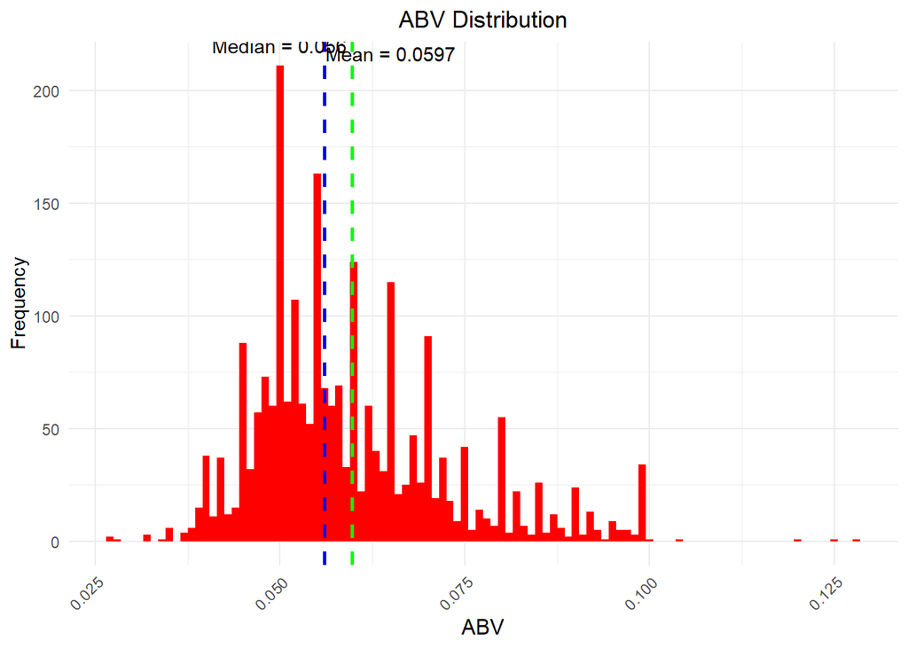

```r
# Calculate median and mean of ABV
median_abv <- median(beers_breweries$ABV, na.rm = TRUE)
mean_abv <- mean(beers_breweries$ABV, na.rm = TRUE)

# Create the histogram
ggplot(beers_breweries, aes(x = ABV)) +
  geom_histogram(binwidth = .001, fill = "red") +
  ggtitle("ABV Distribution") +
  ylab("Frequency") +
  geom_vline(aes(xintercept = median_abv), color = "blue", linetype = "dashed", linewidth = 1) + # Median line
  geom_vline(xintercept = mean_abv, color = "green", linetype = "dashed", linewidth = 1) + # Mean line
  theme_minimal() +
  theme(axis.title.x = element_text(size = 12),  # Increase x-axis label size
        axis.text.x = element_text(angle = 45, hjust = 1),
        plot.title = element_text(hjust = 0.5)) +
  annotate("text", x = .05, y = 210, label = paste("Median =", round(median_abv,4)), vjust = -1) + # Label for median
  annotate("text", x = .065, y = 200, label = paste("Mean =", round(mean_abv,4)), vjust = -2) # Label for mean
```

# 7. Is There an Apparent Relationship Between the Bitterness of the Beer and its Alcoholic Content? Draw a Scatter Plot.

```r
breaks <- c(-Inf, 12, 16, Inf) # Assuming 'Small' is up to 12, 'Medium' is more than 12 and up to 16, 'Large' is more than 16
labels <- c("Small", "Medium", "Large")

# Convert the 'Ounces' variable into a factor with defined levels
beers_breweries <- beers_breweries %>%
  mutate(Ounces_Factor = cut(Ounces, breaks = breaks, labels = labels, include.lowest = TRUE))

# Checking the changes
head(beers_breweries)
```

```
##   Beer_ID   ABV      IBU Brewery_id                          Style Ounces City
## 1    1436 0.050 26.75000        409            American Pale Lager     12 Bend
## 2    2265 0.066 44.94118        178        American Pale Ale (APA)     12 Gary
## 3    2264 0.071 67.34653        178                   American IPA     12 Gary
## 4    2263 0.090 93.32000        178 American Double / Imperial IPA     12 Gary
## 5    2262 0.075 67.34653        178                   American IPA     12 Gary
## 6    2261 0.077 28.09091        178                  Oatmeal Stout     12 Gary
##   State           Beer_Name              Brewery_Name   mean_abv   mean_aBV
## 1    OR            Pub Beer 10 Barrel Brewing Company 0.05121622 0.05121622
## 2    IN         Devil's Cup       18th Street Brewery 0.05457741 0.05457741
## 3    IN Rise of the Phoenix       18th Street Brewery 0.06448926 0.06448926
## 4    IN            Sinister       18th Street Brewery 0.08736893 0.08736893
## 5    IN       Sex and Candy       18th Street Brewery 0.06448926 0.06448926
## 6    IN        Black Exodus       18th Street Brewery 0.05966667 0.05966667
##   mean_IBU mean_ibu Ounces_Factor
## 1 26.75000 26.75000         Small
## 2 44.94118 44.94118         Small
## 3 67.34653 67.34653         Small
## 4 93.32000 93.32000         Small
## 5 67.34653 67.34653         Small
## 6 28.09091 28.09091         Small
```

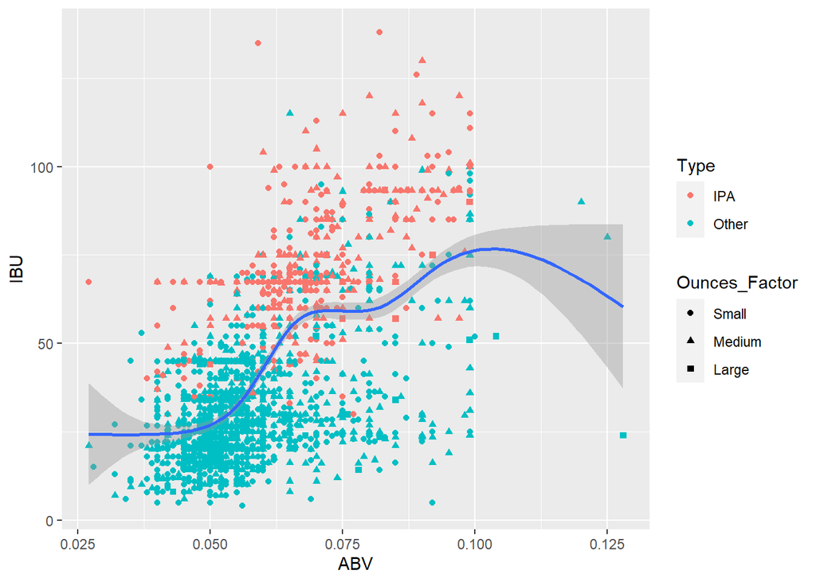

```r
# Creating scatter plot
beers_breweries %>%
  mutate(Type = as.factor(ifelse(grepl("India Pale Ale|IPA",Style, ignore.case = TRUE) == 1, "IPA",
                                  "Other"))) %>%
  ggplot(aes(x = ABV, y = IBU))+
  geom_point(aes(color = Type, shape = Ounces_Factor), position = "dodge") +
  geom_smooth()
```

Generally, an increase in ABV is associated with an increase in IBU. This makes sense because the more bitter beverages on average are IPA’s that have a higher ABV as well. HOWEVER, we can’t generalize and say that this is always the case as there are some beverages that have a high ABV but a very low IBU. There could be other variables as well effecting the relationship between ABV & IBU. The chart also highlights the fact that India Pale Ales (IPA) tend to have a much higher IBU, while most other beers stay in the lower to mid ranges.